BẢN MẪU 04 · Để duyệt nội dung và thiết kế · Các liên kết học liệu chưa kết nối.

**Z****O**MATH

ZO Math · Học liệu miễn phí

# Ôn thi Toán THPT 2027

ĐẾM NGƯỢC ĐẾN BUỔI THI TOÁN

—

—

—

NGÀY

Chờ xác minh lịch thi chính thức.

Chương trình tự học miễn phí dành cho học sinh ôn thi tốt nghiệp THPT 2027. Hiểu kiến thức, tự giải bài và biết mình cần học tiếp điều gì.

Học trong kỉ nguyên trí tuệ nhân tạo,  
học để tìm lại chính mình.

Khám phá học liệu ↓

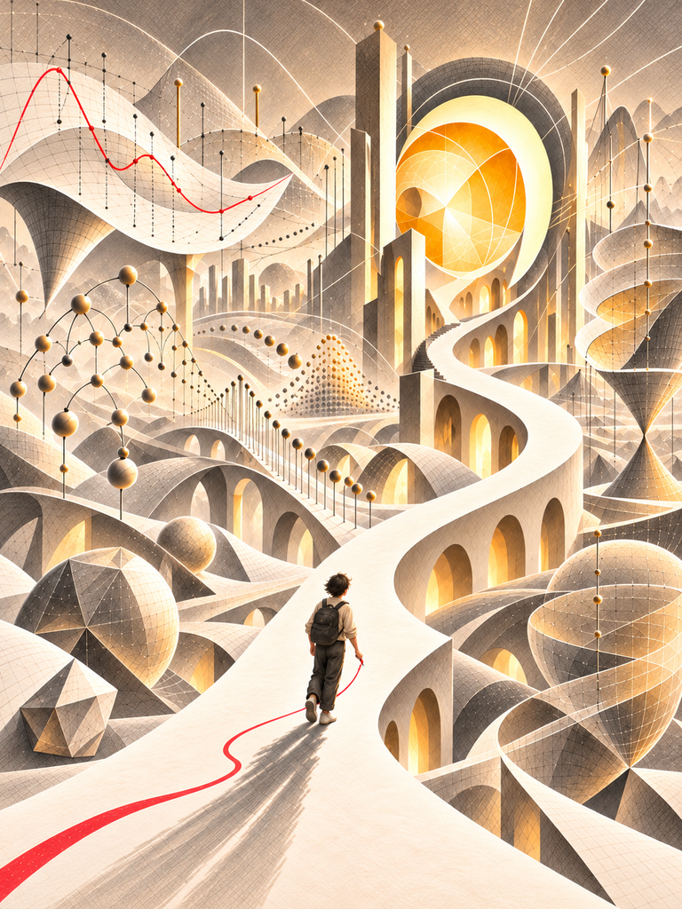

Ôn thi, và học cách tự học

## Biết vì sao. Tự mình làm được.

Một công thức có ý nghĩa gì? Khi nào được dùng? Bảng biến thiên và đồ thị đang nói cùng một điều như thế nào? Từ những câu hỏi ấy, ZO Math giúp em kết nối kiến thức và lựa chọn cách giải có căn cứ.

Em có thể bắt đầu từ phần đang cần ôn. Chỗ nào chưa vững, quay về đúng phần nền; chỗ nào đã hiểu, dành thời gian tự làm và kiểm chứng. Tiến bộ thể hiện ở bài em làm được, điều em giải thích được và lỗi em đã sửa.

Phù hợp với học sinh lớp 12 và người đang ôn lại kiến thức Toán THPT, với nền tảng và mục tiêu khác nhau. Chương trình được phát triển và bổ sung từng gói.

Chọn một gói, bắt đầu một việc học

## Hôm nay, em muốn học gì?

**Chưa biết nên bắt đầu từ đâu?**

D0 giúp em nhìn lại kiến thức đã học và xác định phần cần củng cố.

## Học theo nhịp của em.

Mỗi gói có mục tiêu rõ ràng, bài học, nhiệm vụ tự làm và lời giải để đối chiếu. Em có thể đi tới hoặc quay lại theo nhu cầu.

*01*

### Bài học

Bắt đầu từ câu hỏi, khám phá ý nghĩa, điều kiện và mối liên hệ qua giải thích và ví dụ.

*02*

### Luyện tập

Tự làm theo chặng. Đối chiếu ở Điểm dừng để biết nên đi tiếp hay củng cố điều gì.

*03*

### Kiểm tra

Tự lực làm trọn một lượt để nhìn đúng khả năng hiện tại. Giữ bài làm trước khi xem lời giải.

*04*

### Ôn lại

Trở lại sau một khoảng thời gian, thử nhớ và tự làm để xem kiến thức còn vững đến đâu.

Khi cần, dùng Ôn nền để củng cố kiến thức, Sửa lỗi để hiểu bước sai, Nhật kí để ghi việc học tiếp. Đây là những hỗ trợ bên cạnh mạch học. Riêng khi đang Kiểm tra, em phải tự lực; kết thúc lượt rồi mới nhận hỗ trợ.

Phạm vi chương trình

## Tám mạch, nhiều mối nối.

Kiến thức lớp 10–12 được kết nối theo nhu cầu ôn thi. Đây là phạm vi thiết kế; học liệu sẽ được bổ sung từng phần.

R1Hàm số, đạo hàm, đồ thị

R2Thống kê và đọc dữ liệu

R3Hình học, vectơ và tọa độ

R4Đếm và xác suất

R5Dãy số, mũ và lôgarit

R6Hàm số và phương trình lượng giác

R7Nguyên hàm, tích phân và ứng dụng

R8Mô hình hóa, tối ưu và tổng hợp

Phần nền được gọi vào khi cần: điều kiện, biến đổi đại số, phương trình, đọc hình và các kiến thức phục vụ nhiệm vụ đang học.

ĐANG CHUẨN BỊ · DỊCH VỤ CÓ THU PHÍ

## Học trực tiếp cùng ZO Math.

Dành thời gian cho cách em nghĩ.

Có những chỗ vướng cần một cuộc trao đổi: em hiểu đề thế nào, vì sao chọn cách giải ấy, và điều gì khiến em dừng lại. ZO Math đang chuẩn bị trải nghiệm học trực tiếp, lấy bài làm và câu hỏi của từng người học làm điểm bắt đầu.

Chưa mở đăng ký. Hình thức học, lịch, phạm vi hỗ trợ và mức phí sẽ được công bố khi sẵn sàng.

Trải nghiệm dự kiến

### Nhìn lại điểm xuất phát

1. Cùng xem bài làm, mục tiêu và những điều em đang muốn hiểu rõ.

### Cùng làm rõ cách nghĩ

2. Trao đổi về lập luận, thử cách tiếp cận và tìm nguyên nhân của chỗ vướng.

### Chọn việc tự học tiếp theo

3. Xác định nhiệm vụ phù hợp để em tiếp tục tự làm và kiểm tra lại.

Học liệu của chương trình Ôn thi Toán THPT 2027 vẫn miễn phí. Dịch vụ này là trải nghiệm đồng hành riêng, không phải điều kiện để sử dụng học liệu.

Nền tảng của học liệu

## Có nguồn để đối chiếu. Có lí do cho mỗi bước giải.

ZO Math nghiên cứu từ Chương trình giáo dục phổ thông môn Toán 2018, sách giáo khoa Toán lớp 10–12 và các nguồn đề thi chính thức. Nội dung được tổ chức lại thành bài học, nhiệm vụ và lời giải phục vụ tự học.

Trong mỗi gói, mục Nguồn giúp em tìm căn cứ tham khảo. Ví dụ, cách giải thích và trình tự học do ZO Math biên soạn; chương trình sẽ tiếp tục được rà soát và cập nhật.

**Em nên dùng trí tuệ nhân tạo thế nào khi học?**

Hãy thử tự làm và giữ lại cách nghĩ của mình trước. Khi cần, dùng AI để hỏi về một bước chưa hiểu, yêu cầu một gợi ý hoặc kiểm tra một lập luận; sau đó tự giải thích và làm lại. Khi đang làm bài Kiểm tra, không dùng AI hoặc trợ giúp khác.

## Trước khi bắt đầu

**Em chưa vững kiến thức lớp 10–11 thì có học được không?**

Hãy xem kiến thức cần trước ở đầu gói. Khi gặp chỗ thiếu, quay về đúng phần Ôn nền rồi trở lại nhiệm vụ. Phần chưa từng học cần được học trước; không nên coi mọi câu chưa làm được là do em học yếu.

**Có cần đọc lần lượt hết mọi bài không?**

Không. Nếu đã nắm phần học, em có thể vào Luyện tập. Nếu đã chuẩn bị kĩ hoặc đủ tự tin, em có thể vào Kiểm tra. Kết quả tự làm giúp xác định điều đã vững và điều cần quay lại học.

**Có thể học trên giấy không?**

Các gói có mục Tải PDF. Chọn bản học và bài tập để tự làm; dùng bản đầy đủ hoặc phần lời giải để đối chiếu sau đó.

**Khóa học có thu phí hay yêu cầu ủng hộ không?**

Học liệu của chương trình được chia sẻ miễn phí. Ủng hộ ZO Math hoàn toàn tự nguyện. Dịch vụ học trực tiếp có thu phí dự kiến sẽ được giới thiệu riêng khi sẵn sàng.

## Cùng giữ cánh cửa học Toán luôn mở.

Sự ủng hộ của bạn giúp ZO Math dành thời gian nghiên cứu, kiểm tra lời giải, dựng hình và tiếp tục chia sẻ học liệu Toán miễn phí.

Đóng góp hoàn toàn tự nguyện, không ảnh hưởng đến quyền học và không phải học phí của dịch vụ học trực tiếp.

THÔNG TIN CHUYỂN KHOẢN

**Ngân hàng**

Vietcombank

**Chủ tài khoản**

Nguyễn Tấn Nhựt

**Số tài khoản**

0601000137768

**Nội dung chuyển khoản**

BAO TRO ZO MATH

Ủng hộ tự nguyện, không phải điều kiện để học.